# Assignment 13

10 min: Do a bivariate analysis on the penguins dataset for the following combination of columns:

- species VS sex
- island VS sex

For this bivariate analysis, at least perform the following tasks:

- Do you expect their to be a correlation between the two columns?
- Create a contingency table. Do you observe different ratios between categories here?
- Create a bar plot for this contingency table. Do you observe different ratios between categories here?
- Do a chi-squared test. What does the result say? What's the chance of there being a correlation between the two columns?

```python
import pandas as pd
import seaborn as sns
penguins = sns.load_dataset("penguins")
```

```python
def create_contingency_table(dataset, column1, column2):
    return dataset.groupby([column1, column2]).size().unstack(column1, fill_value=0)

from scipy.stats import chi2_contingency
def check_correlation(dataset, column1, column2):
    contingency_table = create_contingency_table(dataset, column1, column2)
    chi2 = chi2_contingency(contingency_table)
    p_value = chi2[1]
    odds_of_correlation = 1 - p_value
    print(f"The odds of a correlation between {column1} and {column2} is {odds_of_correlation * 100}% (Based on a p value of {p_value}).")
    print("This percentage needs to be at least 95% for a significant correlation.")
```

# Species VS Sex

### Excpectation

Ik denk niet dat er een correlatie bestaat tussen de verschillende soorten en geslacht van de pinguins. Ik denk niet dat er van een soort bijvoorbeeld meer of minder mannetjes zouden zijn.

```python
penguinsContingencyTable = create_contingency_table(penguins, 'species','sex')
print(penguinsContingencyTable)
```

```
species  Adelie  Chinstrap  Gentoo
sex
Female       73         34      58
Male         73         34      61
```

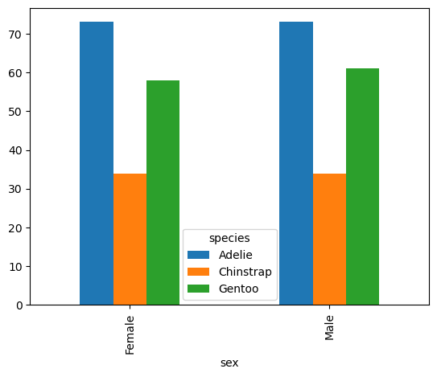

```python
penguinsContingencyTable.plot(kind='bar')
```

```python
check_correlation(penguins, 'species','sex')
```

```
The odds of a correlation between species and sex is 2.4010631023415385% (Based on a p value of 0.9759893689765846).
This percentage needs to be at least 95% for a significant correlation.
```

### Conclusion

Zoals ik had voorspeld is er geen correlatie tussen het geslacht en de soorten pinguins. Van allebei de geslachten zijn er voor beide alle soorten bijna evenveel mannetjes als vrouwtjes pinguins. Het verschil is erg klein en daarom te verwaarlozen. Met de chi-square methode is ook te zien dat de correlatie maar 2.4 procent bedraagt en dat er dus amper correlatie is.

# Island VS Sex

### Excpectation

Ik denk dat er wel een correlatie zou kunnen zijn tussen de verschillende eilanden en het geslacht van de pinguins. Misschien dat de vrouwtjes pinguins op het ene eiland zitten en de mannetjes op het andere en alleen om te paren bij elkaar komen bijvoorbeeld. Of dat er een broed eiland is voor de vrouwtjes pinguins met eieren.

```python
penguinsContingencyTable = create_contingency_table(penguins, 'island','sex')
print(penguinsContingencyTable)
```

```
island  Biscoe  Dream  Torgersen
sex
Female      80     61         24
Male        83     62         23
```

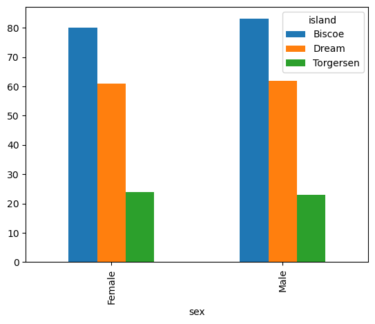

```python
penguinsContingencyTable.plot(kind='bar')
```

```python
check_correlation(penguins, 'island','sex')
```

```
The odds of a correlation between island and sex is 2.8388770718934975% (Based on a p value of 0.971611229281065).
This percentage needs to be at least 95% for a significant correlation.
```

### Conclusion

Mijn verwachting was dat er wel een verband zou zijn tussen de eilanden en het geslacht van de pinguins maar er bluikt geen correlatie te zijn tussen de twee. De chi square geeft ook aan dat er maar 2.8 procent correlatie is wat heel weinig is.